# 1st grade obesity and overweight in Alachua County

## William S. Talbot Elementary

Like many other schools, Talbot Elementary’s 1st grade Hispanic population has the highest obesity rate and the Asian population the lowest. The distribution of obesity by gender varies, showing no clear pattern, except for 2008 in whichthe obesity rate among female’s was 0%. This is due entirely to a very small smaple size for female’s in that year (figure 33). However, the distribution of obesity by lunch status shows a much clearer trend with student’s qualifying for free lunch driving the obesity rate higher.

### Obesity Rate by Year

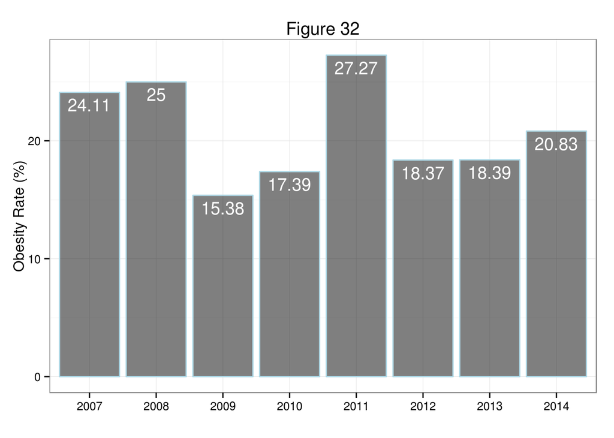

### Obesity rate by race aggregated 2007-2014

[figure not shown]

### Obesity rate by gender (2007-2014)

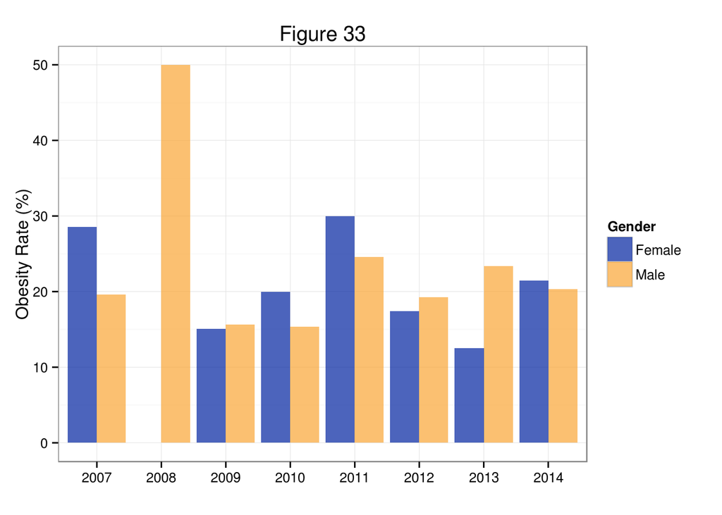

### Obesity rate by lunch status (2007-2014)

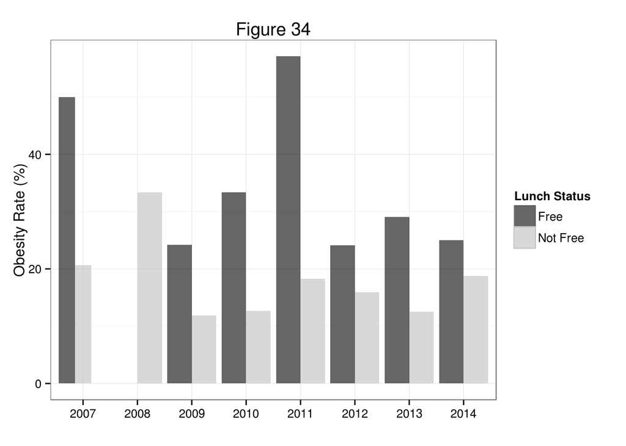

## Terwilliger Elementary

Terwilliger Elementary had 722 1st graders in the time period 2007-2014 and an average obesity rate of 36.15%, the highest among large schools. This higher average obesity rate is largely due to the years 2007 and 2014 (figure 35).

Unlike other schools, the Asian and Black population have the higher average obesity rates in the time period 2007-2014. However, the Asian population is significantly smaller. Multiracial students enjoy the lowest obesity rate among 1st graders (figure 36).

The distribution of obesity by gender varies, showing no clear pattern (figure 37). The same is true for lunch status- there is no significant difference between students qualifying for free lunch and those who do not.

### Obesity Rate by Year

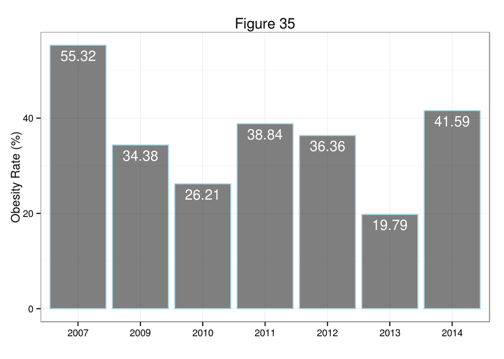

### Obesity rate by race aggregated 2007-2014

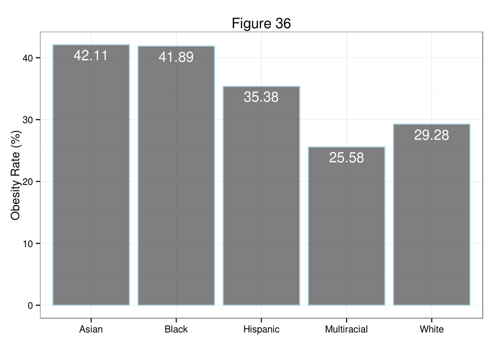

### Obesity rate by gender (2007-2014)

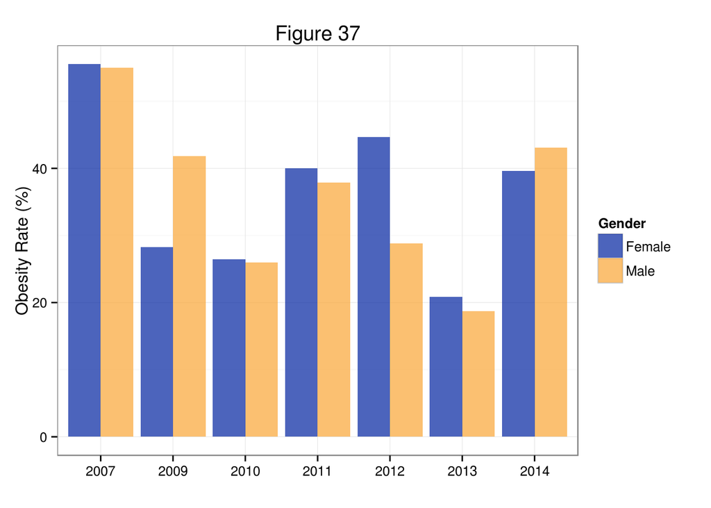

### Obesity rate by lunch status (2007-2014)

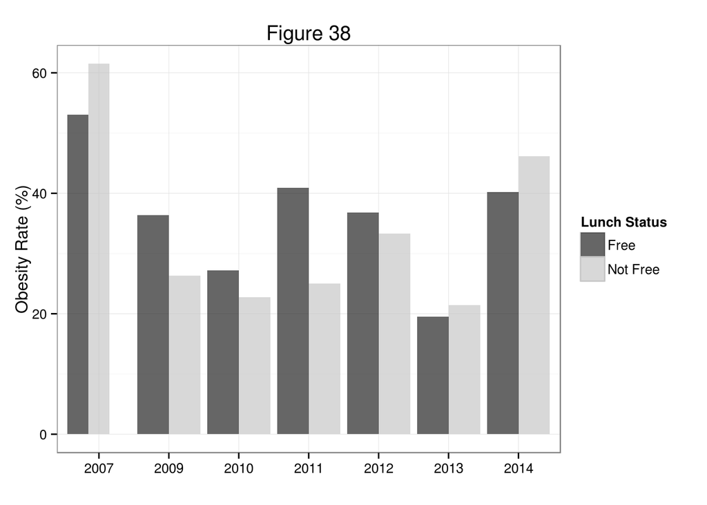

## Kimball Wiles Elementary

Kimball Wiles Elementary had 924 total 1st graders in the time period 2007-2014 and an average obesity rate of 27.06, the median rate for large schools. The average obesity rate for 1st graders at Wiles Elementary rapidly increase from 2007 to 2009 and then dropped off in 2010. It began increasing again until 2012 and settled back down in 2013 and 2014 (figure 39).

In line with other schools, the Hispanic 1st graders at Wiles Elementary have the highest obesity rate whereas Asian students have the lowest (figure 40).

The distribution of obesity by gender varies, showing no clear pattern (figure 41). The peak in obesity rates in 2009 was driven primarily by students qualifying for free lunch. In addition the more recent obesity rates of 2013 and 2014 are also primarily driven by these same students (figure 42. )

### Obesity Rate by Year

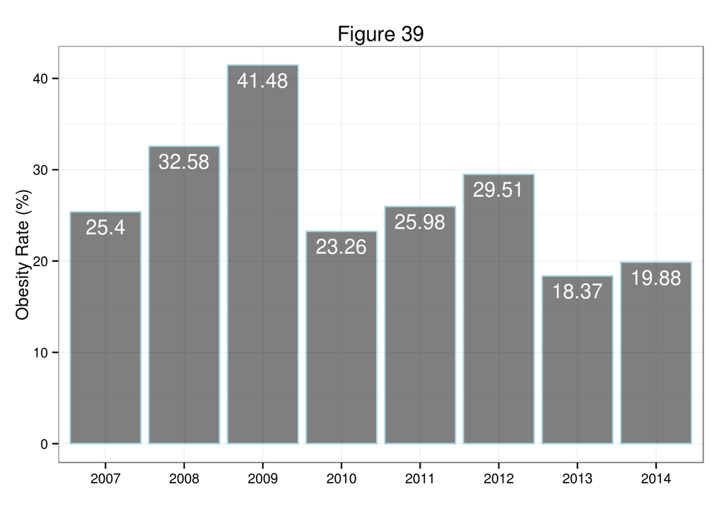

### Obesity rate by race aggregated 2007-2014

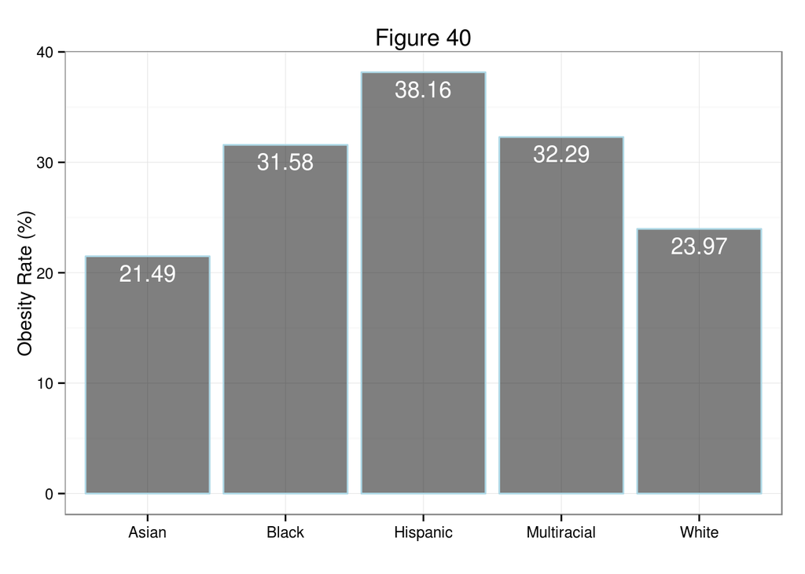

### Obesity rate by gender (2007-2014)

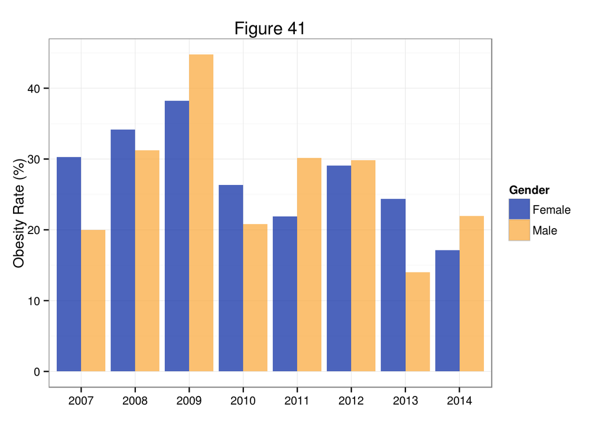

### Obesity rate by lunch status (2007-2014)

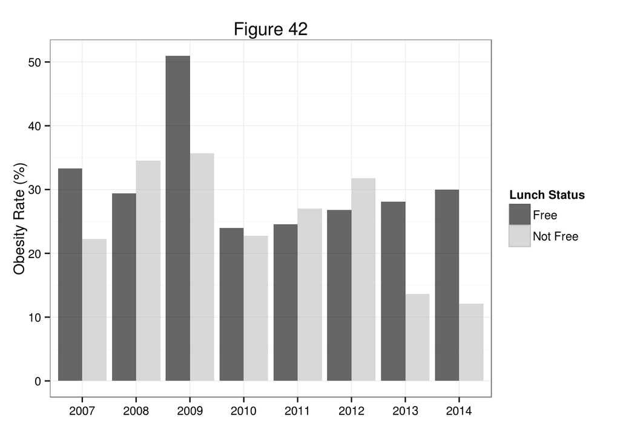